# Contextualização do Pré Processamento de Dados

# Bibliotecas

```r
library(tidyverse)
```

# Introdução

Neste material iremos discutir sobre desafios relacionados a etapa de preparação de dados, usualmente conhecida pela abreviação dataprep. Aqui procuramos garantir que as informações estejam retratando de forma apropriada as variáveis que se propõem a representar.

# Pré-processamento

A etapa de pré-processamento faz uso de todos os recursos que utilizamos até aqui. Contudo, tendo como enfoque a garantir que o dado está sendo devidamente representado, queremos garantir a qualidade da informação. Algumas das ações que podemos relacionar a esta etapa, organizadas por grupos, são:

- Importação
  - Identificar unidade de análise
  - Agregar dados segundo a unidade identificada
  - Tratar registros inválidos e linhas duplicadas
  - Tornar únicos os nomes das colunas
  - Combinar bases de dados
- Perfil
  - Gerar metadados/metainformação dos dados
  - Verificar tipos de dados e unidades de medida
  - Corrigir formatações incorretas
  - Identificar amostras tendenciosas
- Limpeza
  - Remover colunas irrelevantes
  - Filtrar observações fora do escopo de interesse
- Ajustes pré modelagem (**dataprep**)
  - Tratar dados faltantes (missing data)
  - Aplicar codificações
  - Aplicar padronizações

Note que se tratam de ajustes que podem fazer a diferença entre o sucesso e o fracasso da sua análise, e não vou te enganar, isso dá trabalho! Algumas estimativas indicam que até 80% do tempo de uma análise de dados pode se concentrar aqui. Desde o entendimento da origem de um dado faltante, passando por abreviações e espaços extras indevidos, até valores inválidos, tudo isto pode acabar redirecionando a sua análise. Mas é assim que garantimos que os dados estão aptos a representarem a realidade que esperamos que seja retratada.

## E no R?

Como nesta etapa o desafio é mais investigativo e julgamental do que em termos técnicos. Com o que foi visto nos módulos anteriores, você será capaz de endereçar as soluções, apesar de existem pacotes que facilitam determinadas atividades, como por exemplo `codemeta` que nos auxiliar com a criação de metadados, ou o pacote `naniar` que nos auxilia com dados faltantes (falaremos dele logo mais). Mas é importante ressaltar que, em última instância, é uma questão de pesquisar: `library R missing data`, por exemplo — DICA: pesquisas em inglês tendem a ser mais efetivas ;).

O verdadeiro conhecimento nesta etapa é ter um horizonte sobre O QUE precisa ser feito, muito mais do que o COMO aplicar.

## Ajustes pré modelagem (dataprep)

Apesar dos comentários acima, existe um grupo em particular que gostaria de falar um pouco mais. No caso, o grupo que denominamos `Ajustes pré modelagem`, ou ainda dataprep. Tais pré-processamentos são particularmente importantes pois podem ser obrigatórios, a depender da técnica de modelagem que você decida aplicar na etapa de modelagem. Isto porque algumas técnicas não aceitam valores faltantes ou features categóricas como entrada, por exemplo. Sendo assim, teremos uma breve discussão sobre o que envolve cada um dos `dataprep` citados. No caso dos dados faltantes, visto a sua relevância, daremos uma profundidade maior à discussão.

Como pacote de referência para pré-processamentos, utilizaremos o [`recipes`](https://recipes.tidymodels.org/), biblioteca que faz parte do meta-pacote `tidymodels`, indico ainda o anexo do livro [Tidy Modeling with R](https://www.tmwr.org/pre-proc-table.html), do Max Kuhn e da Julia Silge para o tema.

### Aplicar codificações

De forma geral as técnicas de modelagem utilizadas no contexto de análise de dados são capazes de lidar apenas com valores numéricos. De modo que, para que esses dados não sejam disperdiçados utilizamos técnicas de Codificação de Variáveis, que nada mais é do que o processo de transformar variáveis categóricas em númericas, logo, adequadas às técnicas de modelagem que possuem tal restrição.

Existem várias estratégias para fazer isso, sendo importante entender a natureza e características da variável em questão, para julgar qual é a mais adequada para cada contexto. Algumas estratégias comuns são:

Aqui é importante ter em conta pontos como: quantidade de categorias existentes, nosso interesse em manter a interpretabilidade dos resultados, ou ainda pontos relacionados a própria modelagem (como questões de multicolineariedade).Este [artigo do pacote recipes](https://recipes.tidymodels.org/articles/Dummies.html), discute algumas opções relacionadas a features categoricas.

### Aplicar padronizações

Conforme comentado, as técnicas de modelagem lidam, em geral, com valores numéricos e não sabem exatamente o que eles representam. Quando temos variáveis com magnitudes e variações muito diferentes como, por exemplo, idade e salário, o modelo pode assumir que a variável de maior magnitude é mais relevante, o que muitas vezes não é verdade, e dar um peso maior para ela. Por isso utilizamos técnicas de padronização, que são métodos para fazer com que as variáveis tenham uma escala parecida e, muitas vezes, fixa. Com isso garantimos que cada variável tenha uma contribuição parecida no modelo e, em alguns casos, essa técnica também torna o processo de modelagem mais rápido.

Vamos repassar um exemplo:

```r
dados::casas %>%
  select(where(is.numeric)) %>%
  glimpse()
```

```
## Rows: 2,930
## Columns: 35
## $ ordem                           <int> 1, 2, 3, 4, 5, 6, 7, 8, 9, 10, 11, 12,…
## $ lote_fachada                    <int> 141, 80, 81, 93, 74, 78, 41, 43, 39, 6…
## $ lote_area                       <int> 31770, 11622, 14267, 11160, 13830, 997…
## $ construcao_ano                  <int> 1960, 1961, 1958, 1968, 1997, 1998, 20…
## $ remodelacao_ano                 <int> 1960, 1961, 1958, 1968, 1998, 1998, 20…
## $ alvenaria_area                  <int> 112, 0, 108, 0, 0, 20, 0, 0, 0, 0, 0, …
## $ porao_area_com_acabamento_1     <int> 639, 468, 923, 1065, 791, 602, 616, 26…
## $ porao_area_com_acabamento_2     <int> 0, 144, 0, 0, 0, 0, 0, 0, 0, 0, 0, 0, …
## $ porao_area_sem_acabamento       <int> 441, 270, 406, 1045, 137, 324, 722, 10…
## $ porao_area_total                <int> 1080, 882, 1329, 2110, 928, 926, 1338,…
## $ porao_num_banheiros             <int> 1, 0, 0, 1, 0, 0, 1, 0, 1, 0, 0, 1, 0,…
## $ porao_num_banheiros_lavabos     <int> 0, 0, 0, 0, 0, 0, 0, 0, 0, 0, 0, 0, 0,…
## $ primeiro_andar_area             <int> 1656, 896, 1329, 2110, 928, 926, 1338,…
```

[output cut: 22 more lines]

```r
dados_porao <- dados::casas %>%
  select(lote_area, venda_valor, acima_solo_num_comodos, alvenaria_area)


p1 <- dados_porao %>%
  pivot_longer(everything()) %>%
  ggplot(aes(value, name, color = name)) +
  geom_boxplot() +
  theme_minimal() +
  theme(legend.position = "bottom", legend.title=element_blank()) +
  labs(x = "", y = "")


p2 <- dados_porao %>%
  scale() %>%
  as_tibble() %>%
  pivot_longer(everything()) %>%
  ggplot(aes(name, value, color = name)) +
  geom_boxplot() +
  theme_minimal() +
  theme(legend.position = "none") +
  labs(x = "", y = "") +
  ggtitle("Standardization Z-Score") +
  guides(x = "none")


p3 <- dados_porao %>%
  mutate(across(everything(), ~scales::rescale(.x, to = c(0, 1)))) %>%
  pivot_longer(everything()) %>%
  ggplot(aes(name, value, color = name)) +
  geom_boxplot() +
  theme_minimal() +
  theme(legend.position = "none") +
  labs(x = "", y = "") +
  ggtitle("Min-Max Scaling") +
  guides(x = "none")
```

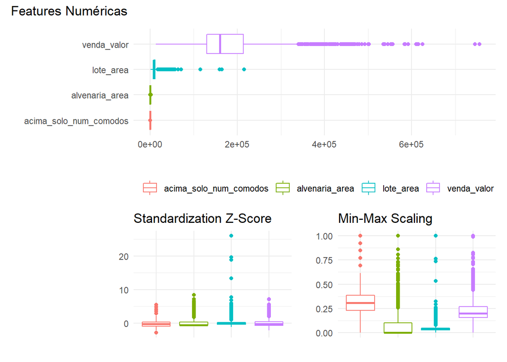

```r
library(patchwork)

p1 / (p2 + p3) +
  plot_annotation(title = 'Features Numéricas')
```

Note a similaridade desta discussão com o módulo sobre as investigações iniciais, particularmente a questão de medidas de sumarização absolutos vs. relativas ;)

### Tratar dados faltantes (missing)

Aqui, nosso objetivo primário deve ser entender qual o mecanismo que causou a ausência dos dados. Tendo como referência a discussão feita no [Capítulo 08 do livro Feature Engineering and Selection: A Practical Approach for Predictive Models](http://www.feat.engineering/handling-missing-data.html), temos como três principais causas de ausência de dados:

- **Deficiência Estrutural** : um nível da variável que foi excluído dos dados. Por exemplo, para uma feature que caracteriza um componente que não existe na maioria das observações, poderia se usada uma categoria para indicar sua inexistência
- **Causas Específicas** : há ocorrência de evento específico que gera a falta de dados, como quando um paciente interrompe sua participação em um estudo clínico devido a um efeito adverso ou morte.
- **Ocorrências Aleatórias** : quando não é possível identificar uma causa específica para a ausência dos dados.

Em termos de endereçamento, existem diferentes modos de atuar. Podemos:

- Deleter a coluna
- Imputar valores
- Criar uma nova categoria

Tendo que, para cada uma dessas, é requerido algum grau de investigação e decisão, como por exemplo: qual será o valor da imputação? A média da coluna? A mediana? Utilizaremos alguma técnica baseada em modelos? Cada caso será um caso.

Vamos agora comentar um pouco sobre o ferramental relacionado aos valores faltantes:

#### no R

Uma vez que você conhece a fonte de origem dos valores faltantes, pode concluir que substitui-los é o melhor caminho. Por exemplo, você pode saber que todos os valores de “N/A”, “NA” e “Não disponível” ou -99 ou -1 devem estar ausentes.

#### pacote tidyr

Comentando um pouco sobre o ferramental, o pacote `tidyr` possui algumas funções para tratar missing data, são elas:

- `drop_na()` - excluí todas as linhas que apresentam elementos faltantes.
- `fill()` - substituí os dados faltantes pelo valor mais recente da referida coluna.
- `replace_na()` - substituí os dados faltantes por um valor especificado.

Alguns exemplos simples

```r
#base para exemplo
  airquality[1:5,]
```

```
##   Ozone Solar.R Wind Temp Month Day
## 1    41     190  7.4   67     5   1
## 2    36     118  8.0   72     5   2
## 3    12     149 12.6   74     5   3
## 4    18     313 11.5   62     5   4
## 5    NA      NA 14.3   56     5   5
```

```r
#exemplo: exclusão das linhas identificadas com NA
  airquality[1:5,] %>% drop_na()
```

```
##   Ozone Solar.R Wind Temp Month Day
## 1    41     190  7.4   67     5   1
## 2    36     118  8.0   72     5   2
## 3    12     149 12.6   74     5   3
## 4    18     313 11.5   62     5   4
```

```r
  airquality[1:5,] %>% fill(c(Ozone, Solar.R))
```

```
##   Ozone Solar.R Wind Temp Month Day
## 1    41     190  7.4   67     5   1
## 2    36     118  8.0   72     5   2
## 3    12     149 12.6   74     5   3
## 4    18     313 11.5   62     5   4
## 5    18     313 14.3   56     5   5
```

```r
  airquality[1:5,] %>% replace_na(list(Ozone=0, Solar.R=0))
```

```
##   Ozone Solar.R Wind Temp Month Day
## 1    41     190  7.4   67     5   1
## 2    36     118  8.0   72     5   2
## 3    12     149 12.6   74     5   3
## 4    18     313 11.5   62     5   4
## 5     0       0 14.3   56     5   5
```

Mas existem pacotes mais robustos, como é o exemplo do pacote naniar:

#### pacote naniar

O pacote naniar fornece maneiras organizadas visando possibilitar o resumo, visualização e manipulação de dados ausentes, garantindo inclusive integração com o pacote ggplot2 e com o universo tidyverse. Vamos conhecer algumas funções considerando a base de dados `airquality`:

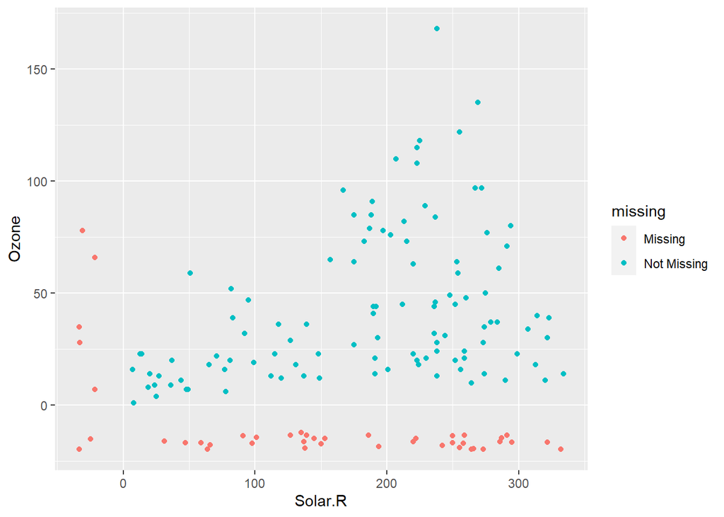

```r
ggplot(airquality,
       aes(x = Solar.R,
           y = Ozone)) +
  naniar::geom_miss_point()
```

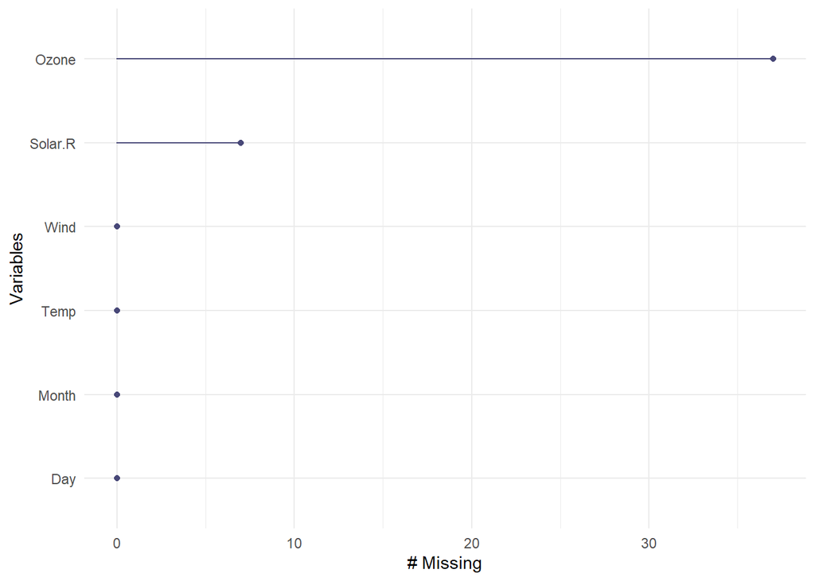

```r
naniar::gg_miss_var(airquality)
```

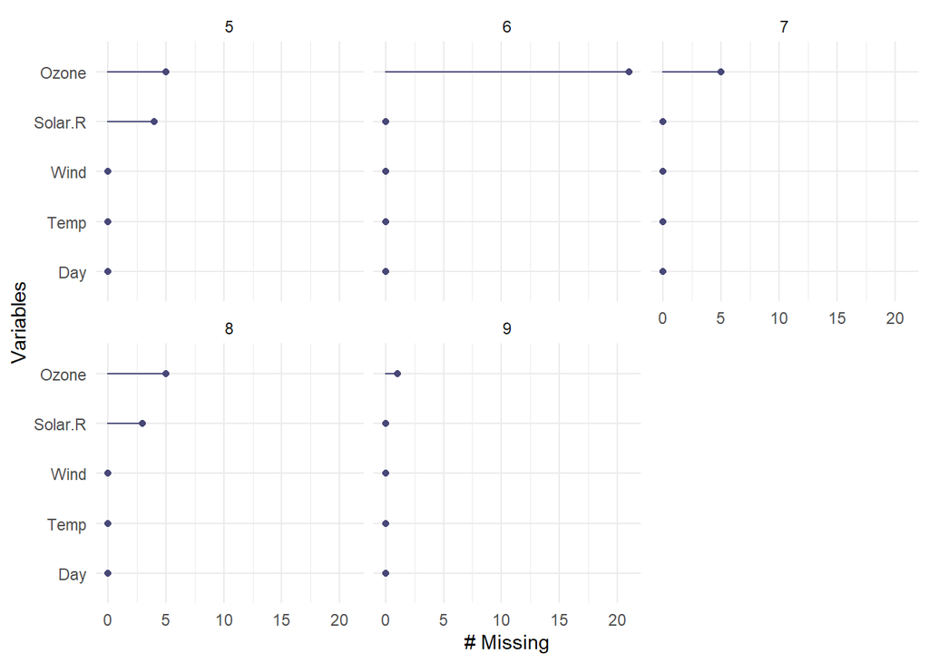

```r
naniar::gg_miss_var(airquality, facet = Month)
```

Para avaliar a análise completa [acesse](https://cran.r-project.org/web/packages/naniar/vignettes/getting-started-w-naniar.html).

# Feature Engineering

Na wikipedia, a definição de Feature Engineering, o que em português seria algo como Engenharia de Atributos é: “descoberta de variáveis, é o processo de usar o conhecimento da área de negócio, para extrair features (características, propriedades, atributos)”. E é exatamente disto que se trata, de traduzir o conhecimento existente em features, de modo que o fênomeno que estamos estudando esteja melhor representado. Gosto muito de pensar na palavra eloquente aqui :)

E como isto tende a ficar muito abstrato, organizei alguns grupos que podem nos ajudar a dar um horizonte maior do que é possível:

- **Evolução** ~ cálculo de tendência, sazonalidade e calendário
  - coeficiente angular, média móvel, dia da semana, etc.
- **Representação** ~ ajuste de unidades de medida
  - Recencia, contagem, proporção, etc
- **Relações funcionais** ~ descrição por meio de funções matemáticas
  - Transformação Box-cox, splines, etc
- **Referências** ~ informações relacionadas à área de estudo
- Conhecimento externo

Em termos ferramentais, aqui estamos novamente no contexto em que saber o que fazer é a parte mais desafiadora. Ainda assim, construir features pode ter suas dificuldades, particularmente se estivermos tratando de dados menos usuais: como textos, datas e fatores. Seguem alguns exemplos destas classes de objetos, considerando os respectivos pacotes do tidyverse.

## textos (stringr)

Variáveis de texto são muito comuns nos bancos de dados e, geralmente, dão bastante trabalho para serem manipuladas. Aqui entra o pacote `stringr`, com ele ganhamos uma sintaxe unificada, o que auxilia na memorização das funções e leitura do código. Como regras básica do pacote: as funções de manipulação de texto começam com `str_`, então caso você esqueça o nome de uma função, basta digitar `stringr::str_` e apertar TAB para ver quais são as opções :)

O primeiro argumento da função é sempre uma string ou um vetor de strings. Como principais funções temos:

- `str_detect()` - identificar a presença de padrões em uma string;
- `str_count()` - contabiliza o número de vezes que um padrão é encontrado;
- `str_replace()` - substitui um dado padrão em uma string;
- `str_to_lower()` - converter strings maiúsculas e minúsculas

```r
#ex.: Quantos `blue` existem na coluna skin_color?

starwars %>%
    #mutate(index_blue = ifelse(skin_color == "blue", "linhas com", "linhas sem")) %>%
    mutate(index_blue = ifelse( str_detect(skin_color, "blue") ,
                                "linhas com", "linhas sem")) %>%
    group_by(index_blue) %>%
    count
```

```
## # A tibble: 2 × 2
## # Groups:   index_blue [2]
##   index_blue     n
##   <chr>      <int>
## 1 linhas com     8
## 2 linhas sem    79
```

```r
#exemplo: como obter a quantidade de palavras contendo a string "berry"
  fruit %>%
    str_count("berry") %>%
    sum()
```

```
## [1] 14
```

### Cheat Sheet

[figure not shown]

Cheat Sheet stringr

## datas (lubridate)

Trabalhar com datas em qualquer linguagemm de programação costuma dar alguma dor de cabeça, muitas vezes com as lógicas sendo alteradas de acordo com o tipo do objeto que você está usando (data, hora, data/hora).Contudo, com o pacote {lubridate} passamos a ter uma sintaxe rica, contemplando :

- `as_date()` - converter um objeto para uma data ou hora
- `wday()` - retorna o dia da semana como um número decimal
- `today()` - retorna a data corrente
- `floor_date()` - arredonda para o limite inferior mais próximo da unidade de tempo

```r
#exemplo: retorna erro por não ser uma data válida
  birthday <- lubridate::dmy("29/02/1971")
#data ok
  birthday <- lubridate::dmy("29/02/1972"); birthday
```

```
## [1] "1972-02-29"
```

```r
#carregando `lubridate`, tornando o prefixo `lubridate::` desnecessário
  library(lubridate)

#obtenção do dia da semana da data especificada
  wday(birthday, label = TRUE)
```

```
## [1] ter
## Levels: dom < seg < ter < qua < qui < sex < sáb
```

As funções date() e as_date() assumem que a ordem segue o padrão da língua inglesa: ano-mês-dia (ymd). A função dmy() resolve esse problema estabelecendo explicitamente a ordem dia-mês-ano. Existem funções para todas as ordens possíveis: dmy(), mdy(), myd(), ymd(), ydm() etc.

Uma grande facilidade que essas funções trazem é poder criar objetos com classe date a partir de números e strings em diversos formatos.

```r
data_string <- "21-10-2015"
class(data_string)
```

```
## [1] "character"
## [1] "character"
```

```r
data_date <- date(data_string)
class(data_date)
```

```
## [1] "Date"
## [1] "Date"
```

```r
data_date
```

```
## [1] "0021-10-20"
## [1] "0021-10-20"
```

```r
data_as_date <- as_date(data_string)
class(data_as_date)
```

```
## [1] "Date"
## [1] "Date"
```

```r
data_as_date
```

```
## [1] NA
## [1] NA
```

```r
data_mdy <- dmy(data_string)
class(data_mdy)
```

```
## [1] "Date"
## [1] "Date"
```

```r
data_mdy
```

```
## [1] "2015-10-21"
## [1] "2015-10-21"
```

```r
#lubridate::

library(lubridate)

dmy(21102015)
```

```
## [1] "2015-10-21"
## [1] "2015-10-21"
```

```r
dmy("21102015")
```

```
## [1] "2015-10-21"
## [1] "2015-10-21"
```

```r
dmy("21/10/2015")
```

```
## [1] "2015-10-21"
## [1] "2015-10-21"
```

```r
dmy("21.10.2015")
```

```
## [1] "2015-10-21"
## [1] "2015-10-21"
```

```r
temp1 <- ymd_hms("2010-08-03 00:50:50") ; temp1
```

```
## [1] "2010-08-03 00:50:50 UTC"
```

```r
temp2 <- date(temp1) - today() ; temp2
## Time difference of -4463 days
temp3 <- temp1 + months(3) + weeks(1) ; temp3
```

```
## [1] "2010-11-10 00:50:50 UTC"
```

```r
rm(temp1, temp2, temp3)
```

### Cheat Sheet

[figure not shown]

Cheat Sheet lubridate

## fatores (forcats)

Grande parte da frustração associada ao uso de fatores no R existe por conta da falta de algumas ferramentas úteis no pacote base. As principais funções do forcats servem para alterar a ordem e modificar os níveis de um fator:

- `fct_count()` - conta o número de valores de cada nível;
- `fct_relevel()` - reordenar os níveis dos fatores;
- `fct_explicit_na()` - adicionar o NA como um dos níveis

```r
#base para exemplo
  gss_cat %>% glimpse
```

```
## Rows: 21,483
## Columns: 9
## $ year    <int> 2000, 2000, 2000, 2000, 2000, 2000, 2000, 2000, 2000, 2000, 20…
## $ marital <fct> Never married, Divorced, Widowed, Never married, Divorced, Mar…
## $ age     <int> 26, 48, 67, 39, 25, 25, 36, 44, 44, 47, 53, 52, 52, 51, 52, 40…
## $ race    <fct> White, White, White, White, White, White, White, White, White,…
## $ rincome <fct> $8000 to 9999, $8000 to 9999, Not applicable, Not applicable, …
## $ partyid <fct> "Ind,near rep", "Not str republican", "Independent", "Ind,near…
## $ relig   <fct> Protestant, Protestant, Protestant, Orthodox-christian, None, …
## $ denom   <fct> "Southern baptist", "Baptist-dk which", "No denomination", "No…
## $ tvhours <int> 12, NA, 2, 4, 1, NA, 3, NA, 0, 3, 2, NA, 1, NA, 1, 7, NA, 3, 3…
```

```r
#exemplo: contabilizando a quantidade de raças declaradas
  gss_cat$race %>%
  fct_count()
```

```
## # A tibble: 4 × 2
##   f                  n
##   <fct>          <int>
## 1 Other           1959
## 2 Black           3129
## 3 White          16395
## 4 Not applicable     0
```

```r
starwars %>%
  mutate(gender = fct_explicit_na(gender)) %>%
  group_by(gender) %>%
  count
```

```
## # A tibble: 3 × 2
## # Groups:   gender [3]
##   gender        n
##   <fct>     <int>
## 1 feminine     17
## 2 masculine    66
## 3 (Missing)     4
## # A tibble: 3 x 2
## # Groups:   gender [3]
##   gender        n
##   <fct>     <int>
## 1 feminine     17
## 2 masculine    66
## 3 (Missing)     4
```

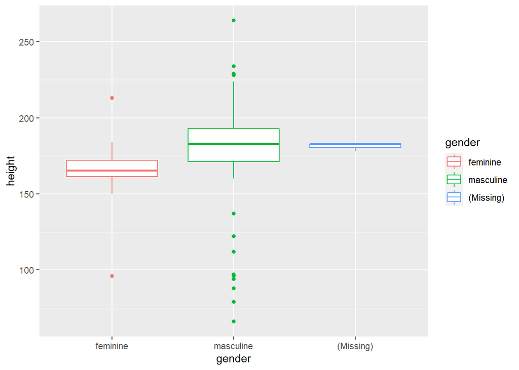

```r
starwars %>%
    mutate(gender = fct_explicit_na(gender)) %>%
    mutate(gender = fct_relevel(gender)) %>%
    ggplot(aes(gender, height, color = gender)) +
    geom_boxplot()
```

### Cheat Sheet

[figure not shown]

Cheat Sheet forcats

# Considerações Finais

Visto existirem muitos termos que são relacionados aos temas discutidos neste módulo, montei um pequeno resumo que espero que ajude.

- **Pré-processamento** trata de: representação, qualidade e limpeza. Tem como termos próximos, isto é, termos que possuem objetivos próximos, e/ou que irão retornar discussões importantes relacionadas ao tema: Data Wrangling, Data Munging, Data Cleaning, Cleansing e Data Integrity.
- **Engenharia de Atributos**: Eloquência, Interpretabilidade, e Otimização de processamento. E tem como termos próximos, seguindo a mesma lógica do tópico anterior: Feature Engineering, Feature Extraction, Feature Selection e Data Transformation.

Sempre vale lembrar sobre como termos em inglês retornam mais resultados para estes temas, “engenharia de atributos” por exemplo soa até estranho para os ouvidos, pois o mais usual é a denominação “Feature Engineering”.

# MÃO NA MASSA!

- o pacote `naniar` se mostrou uma ferramenta interessante no contexto de `missing data`, mas não exploramos todos os seus recursos. Por exemplo, a sequência de funções abaixo nos possibilita avaliar se existe uma mudança na distribuição dos dados faltantes. Considerando o output gráfico, você diria que estamos lidando com qual tipo de missing aqui? Parece ser o caso de dados faltantes aleatórios?

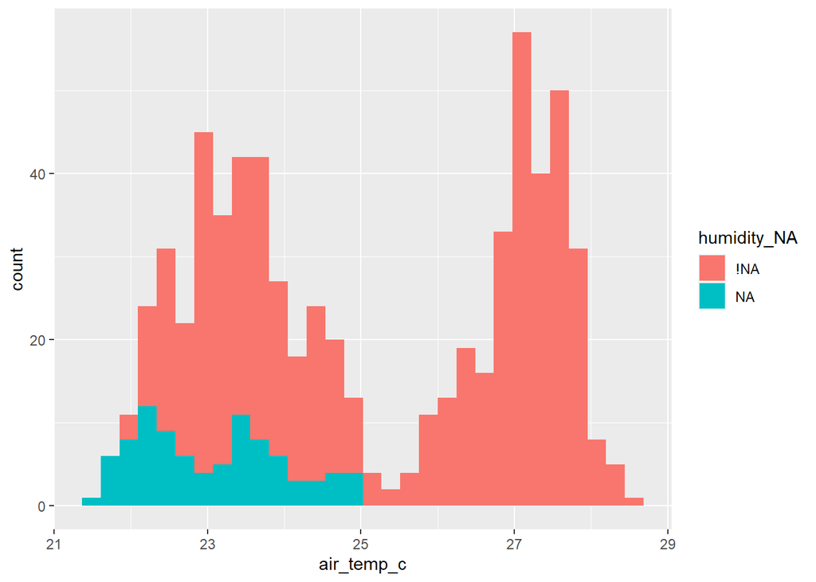

```r
naniar::oceanbuoys %>%
    naniar::bind_shadow() %>%
    ggplot(aes(x = air_temp_c,
               fill = humidity_NA)) +
        geom_histogram()
## `stat_bin()` using `bins = 30`. Pick better value with `binwidth`.
## Warning: Removed 81 rows containing non-finite values (stat_bin).
```

- O livro [Feature Engineering and Selection: A Practical Approach for Predictive Models](http://www.feat.engineering/) é uma das minhas referências preferidas! Não apenas pelos excelentes cases e discussões, mas por procurar desenvolver o(a) leitor(a) não apenas em termos técnicos, mas também com a intuição das técnicas. A tarefa aqui é: leia a seção de introdução de cada um dos capítulos para evoluir nos assuntos aqui abordados. Recomendo particularmente a leitura sobre encoding, do capítulo 5.